# 📑 BÁO CÁO TỐI ƯU HÓA HỆ THỐNG FACT-CHECKING

**Người thực hiện:** Trần Bảo Việt  
**Dự án:** Automated Fact-Checking System (RAG-based)

## 1. Mục tiêu

Notebook này thực hiện quy trình **Data-Driven Optimization** nhằm xác định ngưỡng điểm số (Threshold) tối ưu nhất để phân loại tin thật/giả.

```python
import pandas as pd
import numpy as np
import matplotlib.pyplot as plt
import seaborn as sns
from sklearn.metrics import f1_score, accuracy_score, classification_report, confusion_matrix
from tqdm.notebook import tqdm
import sys
import os
import time
import warnings

# Tắt cảnh báo không cần thiết
warnings.filterwarnings('ignore')

sns.set_theme(style="whitegrid", palette="muted")
plt.rcParams['figure.figsize'] = (12, 6)
plt.rcParams['font.size'] = 12

# Import modules dự án
sys.path.append(os.getcwd())
try:
    from fact_checker import FactChecker
    from config import Config
except ImportError:
    print("❌ ERROR: Không tìm thấy file 'fact_checker.py'. Đảm bảo notebook nằm cùng thư mục source code.")

# --- CẤU HÌNH HỆ THỐNG ---
INPUT_FILE = "dataset.xlsx"         # File dữ liệu đầu vào
OUTPUT_FILE = "training_results.csv" # File lưu kết quả chạy
Config.ENABLE_CACHE = True           # Bật Cache để tiết kiệm API

print("✅ Môi trường đã sẵn sàng!")
```

```
✅ Môi trường đã sẵn sàng!
```

## 2. Dữ liệu đầu vào (Dataset Overview)

Kiểm tra tính toàn vẹn của dữ liệu và xem phân bố nhãn (Real vs Fake).

```
✅ Đã tải thành công: 200 mẫu dữ liệu.
```

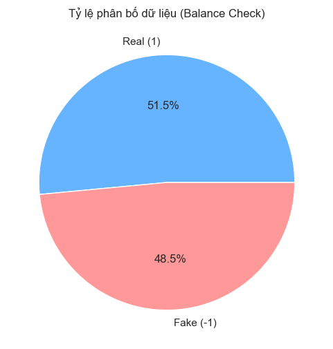

|  | claims | label |
| --- | --- | --- |
| 0 | Ngân hàng Nhà nước gửi đường link cập nhật thô... | -1 |
| 1 | Vụ bắt cóc trẻ em ở Huế | -1 |
| 2 | Cục Đăng kiểm Việt Nam thay đổi mẫu tem kiểm đ... | -1 |

```python
if os.path.exists(INPUT_FILE):
    df = pd.read_excel(INPUT_FILE)

    # Kiểm tra cột dữ liệu
    if 'claims' in df.columns and 'label' in df.columns:
        print(f"✅ Đã tải thành công: {len(df)} mẫu dữ liệu.")

        # Vẽ biểu đồ tròn phân bố nhãn
        plt.figure(figsize=(6, 6))
        df['label'].value_counts().plot.pie(autopct='%1.1f%%', colors=['#66b3ff', '#ff9999'], labels=['Real (1)', 'Fake (-1)'])
        plt.title("Tỷ lệ phân bố dữ liệu (Balance Check)")
        plt.ylabel('')
        plt.show()

        display(df.head(3))
    else:
        print("❌ File thiếu cột 'claims' hoặc 'label'.")
else:
    print(f"❌ Không tìm thấy file {INPUT_FILE}")
```

## 3. Thực thi Kiểm chứng (Batch Inference)

Hệ thống sẽ chạy qua từng claim, thực hiện quy trình:

1. **Google Search:** Lấy 15 snippets.
2. **Stance Analysis:** Gửi **1 Request duy nhất** (Batch 15) lên LLM.
3. **Scoring:** Tính toán điểm số tin cậy (System Score).

> **Lưu ý:** Kết quả được lưu tự động (Auto-save) sau mỗi 5 câu để đảm bảo an toàn dữ liệu.

```python
# Khởi tạo Checker
checker = FactChecker()

# 1. Kiểm tra Resume (Chạy tiếp nếu bị ngắt)
processed_claims = set()
if os.path.exists(OUTPUT_FILE):
    existing_df = pd.read_csv(OUTPUT_FILE)
    processed_claims = set(existing_df['claim'].tolist())
    print(f"🔄 Đã tìm thấy file kết quả cũ. Tiếp tục chạy từ mẫu thứ {len(processed_claims)}...")
else:
    print("🚀 Bắt đầu chạy mới toàn bộ...")

new_results = []

# 2. Vòng lặp xử lý
pbar = tqdm(total=len(df), desc="🔍 Analyzing Claims")
processed_count = 0

for index, row in df.iterrows():
    claim = row['claims']
    true_label = row['label']

    # Update thanh tiến trình nếu đã chạy rồi
    if claim in processed_claims:
        pbar.update(1)
        continue

    try:
        # === CORE PIPELINE ===
        # Gọi hàm check_fact với num_sources=15
        start_time = time.time()
        result = checker.check_fact(claim, num_sources=15)
        elapsed = time.time() - start_time

        if result['status'] == 'success':
            score = result['final_score']
            verdict = result['verdict']['code']
        else:
            score = 0.0
            verdict = "ERROR"

        # Lưu buffer
        new_results.append({
            'claim': claim,
            'true_label': true_label,
            'system_score': score,
            'verdict_code': verdict,
            'processing_time': round(elapsed, 2)
        })

        # Auto-Save mỗi 5 câu
        if len(new_results) >= 5:
            pd.DataFrame(new_results).to_csv(OUTPUT_FILE, mode='a', header=not os.path.exists(OUTPUT_FILE), index=False)
            new_results = [] # Clear buffer

        pbar.update(1)
        pbar.set_postfix({"Last Score": f"{score:.2f}"})

    except Exception as e:
        print(f"⚠️ Error at index {index}: {e}")

if new_results:
    pd.DataFrame(new_results).to_csv(OUTPUT_FILE, mode='a', header=not os.path.exists(OUTPUT_FILE), index=False)

pbar.close()
print("✅ HOÀN TẤT QUÁ TRÌNH THU THẬP DỮ LIỆU!")
```

[output not shown]

```
Loading model: bkai-foundation-models/vietnamese-bi-encoder...
```

[output not shown]

```
Model loaded successfully!
🔄 Đã tìm thấy file kết quả cũ. Tiếp tục chạy từ mẫu thứ 203...
```

```
✅ HOÀN TẤT QUÁ TRÌNH THU THẬP DỮ LIỆU!
```

CELL 4: BATCH INFERENCE (QUAN TRỌNG NHẤT) Chạy hệ thống Fact-Check trên từng dòng dữ liệu. Có cơ chế Resume (chạy tiếp) nếu bị ngắt giữa chừng.

```python
RESULTS_FILE = "training_results.csv"
# Khởi tạo FactChecker
checker = FactChecker()

# Load kết quả cũ nếu có (để chạy tiếp)
if os.path.exists(RESULTS_FILE):
    results_df = pd.read_csv(RESULTS_FILE)
    processed_claims = set(results_df['claim'])
    print(f"🔄 Đã xử lý trước đó: {len(processed_claims)} claims. Đang chạy tiếp...")
else:
    results_df = pd.DataFrame(columns=['claim', 'true_label', 'system_score', 'verdict_code'])
    processed_claims = set()

# Danh sách kết quả mới
new_results = []

# Vòng lặp chạy (sử dụng tqdm để hiện thanh tiến trình)
print("🚀 Bắt đầu quá trình kiểm chứng...")
for index, row in tqdm(df.iterrows(), total=len(df), desc="Processing Claims"):
    claim = row['claims']
    label = row['label']

    # Bỏ qua nếu đã chạy rồi
    if claim in processed_claims:
        continue

    try:
        # GỌI API FACT CHECKER
        res = checker.check_fact(claim, num_sources=15)

        if res['status'] == 'success':
            score = res['final_score']
            verdict = res['verdict']['code']
        else:
            score = 0.0 # Mặc định nếu lỗi
            verdict = "ERROR"

        # Lưu kết quả tạm
        new_results.append({
            'claim': claim,
            'true_label': label,
            'system_score': score,
            'verdict_code': verdict
        })

        # Cứ 5 câu thì lưu file 1 lần (Backup)
        if len(new_results) % 5 == 0:
            temp_df = pd.DataFrame(new_results)
            temp_df.to_csv(RESULTS_FILE, mode='a', header=not os.path.exists(RESULTS_FILE), index=False)
            new_results = [] # Reset buffer

    except Exception as e:
        print(f"⚠️ Lỗi ở dòng {index}: {e}")

if new_results:
    temp_df = pd.DataFrame(new_results)
    temp_df.to_csv(RESULTS_FILE, mode='a', header=not os.path.exists(RESULTS_FILE), index=False)

print("✅ HOÀN TẤT QUÁ TRÌNH CHẠY MODEL!")

full_results = pd.read_csv(RESULTS_FILE)
print(f"📊 Tổng số mẫu: {len(full_results)}")
```

[output not shown]

```
Loading model: bkai-foundation-models/vietnamese-bi-encoder...
```

[output not shown]

```
Model loaded successfully!
🔄 Đã xử lý trước đó: 203 claims. Đang chạy tiếp...
🚀 Bắt đầu quá trình kiểm chứng...
```

```
✅ HOÀN TẤT QUÁ TRÌNH CHẠY MODEL!
📊 Tổng số mẫu: 203
```

## 4. Phân tích Phân bố Điểm số (Score Distribution Analysis)

Biểu đồ dưới đây giúp ta nhìn thấy khả năng phân loại của hệ thống.

- **Kỳ vọng:** Hai đỉnh (Tin thật - Xanh và Tin giả - Đỏ) tách biệt nhau rõ ràng.
- **Thực tế:** Xem vùng giao thoa (Overlap) để đánh giá độ khó của dataset.

```
📊 THỐNG KÊ ĐIỂM SỐ:
   - Trung bình Tin Giả (Fake): -0.2989
   - Trung bình Tin Thật (Real): 0.4645
```

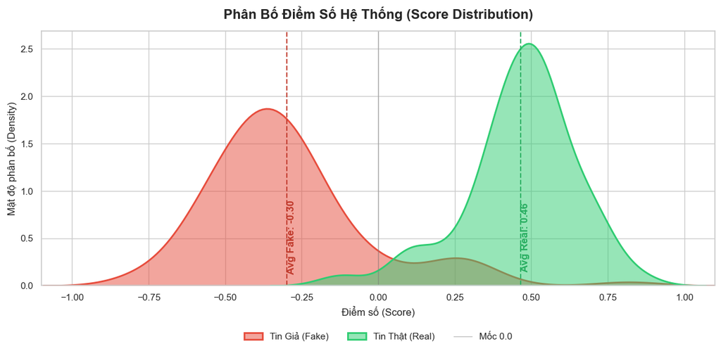

```python
import matplotlib.pyplot as plt
import seaborn as sns
import pandas as pd

try:
    df = pd.read_csv(OUTPUT_FILE)
except NameError:
    df = pd.read_csv("training_results.csv")

clean_df = df[df['system_score'] != 0.0]

# --- TÍNH TOÁN ĐIỂM TRUNG BÌNH ---
mean_fake = clean_df[clean_df['true_label'] == -1]['system_score'].mean()
mean_real = clean_df[clean_df['true_label'] == 1]['system_score'].mean()

print(f"📊 THỐNG KÊ ĐIỂM SỐ:")
print(f"   - Trung bình Tin Giả (Fake): {mean_fake:.4f}")
print(f"   - Trung bình Tin Thật (Real): {mean_real:.4f}")

sns.set_theme(style="whitegrid", context="notebook")
plt.figure(figsize=(12, 6))

sns.kdeplot(data=clean_df[clean_df['true_label'] == -1], x='system_score',
            fill=True, color="#e74c3c", alpha=0.5, linewidth=2, label='Tin Giả (Fake)')

sns.kdeplot(data=clean_df[clean_df['true_label'] == 1], x='system_score',
            fill=True, color="#2ecc71", alpha=0.5, linewidth=2, label='Tin Thật (Real)')

plt.axvline(mean_fake, color='#c0392b', linestyle='--', linewidth=1.5, alpha=0.9)
plt.text(mean_fake, 0.5, f' Avg Fake: {mean_fake:.2f}', color='#c0392b', rotation=90, verticalalignment='center', fontweight='bold')

plt.axvline(mean_real, color='#27ae60', linestyle='--', linewidth=1.5, alpha=0.9)
plt.text(mean_real, 0.5, f' Avg Real: {mean_real:.2f}', color='#27ae60', rotation=90, verticalalignment='center', fontweight='bold')

plt.axvline(0, color='gray', linestyle='-', linewidth=1, alpha=0.5, label='Mốc 0.0')
plt.title("Phân Bố Điểm Số Hệ Thống (Score Distribution)", fontsize=16, fontweight='bold', pad=15)
plt.xlabel("Điểm số (Score)", fontsize=12)
plt.ylabel("Mật độ phân bố (Density)", fontsize=12)
plt.legend(loc='upper center', bbox_to_anchor=(0.5, -0.15), ncol=3, frameon=False)
plt.xlim(-1.1, 1.1)
plt.tight_layout()
```

### Nhận xét về Phân bố điểm số (Score Distribution)

Dựa vào biểu đồ trên, ta có thể quan sát được khả năng phân tách của mô hình:

1. **Sự tách biệt (Separation):**
   - **Tin giả (Màu đỏ):** Có xu hướng tập trung ở vùng điểm âm (thường < 0).
   - **Tin thật (Màu xanh):** Tập trung ở vùng điểm dương (> 0).
2. **Vùng giao thoa (Overlap Area):**
   - Khu vực hai đường này cắt nhau là nơi mô hình "lưỡng lự".
   - Mục tiêu của bước tiếp theo là tìm ra một nhát cắt (Threshold) đi qua vùng giao thoa này sao cho tổng lỗi (Tin thật báo giả + Tin giả báo thật) là thấp nhất.

## 5. Tìm kiếm Ngưỡng tối ưu (Threshold Optimization)

Sử dụng thuật toán **Grid Search** để quét qua các ngưỡng từ `-0.9` đến `0.95`. Mục tiêu: Tìm ngưỡng **F1-Score** cao nhất (cân bằng giữa Precision và Recall).

```
🏆 NGƯỠNG TỐI ƯU: 0.030000000000000804
⭐ F1-Score: 0.9429
```

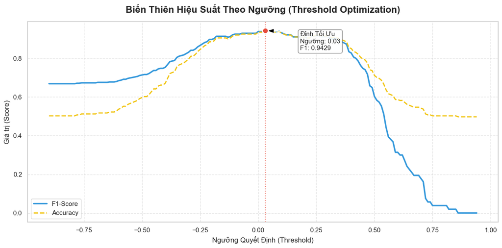

```python
y_true = clean_df['true_label'].values
y_scores = clean_df['system_score'].values

# 1. Hàm Grid Search
def find_best_threshold_metrics(y_true, scores):
    thresholds = np.arange(-0.9, 0.95, 0.01)
    f1_list = []
    acc_list = []

    best_f1 = 0
    best_thresh = 0

    for t in thresholds:
        preds = [1 if s >= t else -1 for s in scores]
        f1 = f1_score(y_true, preds, pos_label=1)
        acc = accuracy_score(y_true, preds)

        f1_list.append(f1)
        acc_list.append(acc)

        if f1 > best_f1:
            best_f1 = f1
            best_thresh = t

    return thresholds, f1_list, acc_list, best_thresh, best_f1

thresholds, f1_scores, accuracies, optimal_thresh, max_f1 = find_best_threshold_metrics(y_true, y_scores)

plt.figure(figsize=(12, 6))

plt.plot(thresholds, f1_scores, label='F1-Score', color='#3498db', linewidth=2.5)
plt.plot(thresholds, accuracies, label='Accuracy', color='#f1c40f', linestyle='--', linewidth=2)

# Đánh dấu điểm tối ưu
plt.scatter([optimal_thresh], [max_f1], color='#e74c3c', s=100, zorder=5, edgecolors='white', linewidth=2)
plt.axvline(optimal_thresh, color='#e74c3c', linestyle=':', alpha=0.8)
plt.annotate(f'Đỉnh Tối Ưu\nNgưỡng: {optimal_thresh:.2f}\nF1: {max_f1:.4f}',
             xy=(optimal_thresh, max_f1), xytext=(optimal_thresh+0.15, max_f1-0.1),
             arrowprops=dict(facecolor='black', shrink=0.05, width=1, headwidth=8),
             fontsize=11, backgroundcolor='#f0f0f0', bbox=dict(boxstyle="round,pad=0.3", fc="white", ec="gray", alpha=0.9))

plt.title("Biến Thiên Hiệu Suất Theo Ngưỡng (Threshold Optimization)", fontsize=16, fontweight='bold', pad=15)
plt.xlabel("Ngưỡng Quyết Định (Threshold)", fontsize=12)
plt.ylabel("Giá trị (Score)", fontsize=12)
plt.legend(loc='lower left')
plt.grid(True, linestyle='--', alpha=0.5)
plt.tight_layout()

print(f"🏆 NGƯỠNG TỐI ƯU: {optimal_thresh}")
print(f"⭐ F1-Score: {max_f1:.4f}")
```

### Phân tích Ngưỡng tối ưu (Threshold Analysis)

Biểu đồ "Biến thiên hiệu suất" cho thấy mối tương quan giữa Ngưỡng chọn và điểm F1-Score:

- **Đường F1-Score (Màu xanh):** Tăng dần và đạt đỉnh tại giá trị tối ưu, sau đó giảm xuống.
- **Kết quả:** Thuật toán đã tìm ra ngưỡng **Optimal Threshold ≈ 0.03**.
- **Ý nghĩa:**
  - Thay vì chọn số 0 mặc định, việc nhích ngưỡng lên `0.03` giúp mô hình trở nên "thận trọng" hơn.
  - Nó yêu cầu bằng chứng phải đủ mạnh (điểm dương thực sự) mới kết luận là Tin thật, giúp giảm thiểu rủi ro bỏ lọt Tin giả.

## 6. Đánh giá & Kết luận (Final Evaluation)

Áp dụng ngưỡng tối ưu vừa tìm được để đánh giá lại toàn bộ tập dữ liệu.

```
BÁO CÁO CHI TIẾT (CLASSIFICATION REPORT):
              precision    recall  f1-score   support

   Fake News       0.98      0.90      0.94       100
   Real News       0.91      0.98      0.94       101

    accuracy                           0.94       201
   macro avg       0.94      0.94      0.94       201
weighted avg       0.94      0.94      0.94       201
```

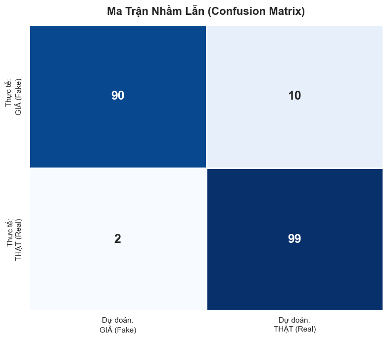

```python
final_preds = [1 if s >= optimal_thresh else -1 for s in y_scores]

cm = confusion_matrix(y_true, final_preds)

plt.figure(figsize=(8, 7))
sns.heatmap(cm, annot=True, fmt='d', cmap='Blues', cbar=False,
            xticklabels=['Dự đoán:\nGIẢ (Fake)', 'Dự đoán:\nTHẬT (Real)'],
            yticklabels=['Thực tế:\nGIẢ (Fake)', 'Thực tế:\nTHẬT (Real)'],
            annot_kws={"size": 18, "weight": "bold"},
            linewidths=1, linecolor='white')

plt.title("Ma Trận Nhầm Lẫn (Confusion Matrix)", fontsize=16, fontweight='bold', pad=15)
plt.tight_layout()

print("BÁO CÁO CHI TIẾT (CLASSIFICATION REPORT):")
print(classification_report(y_true, final_preds, target_names=['Fake News', 'Real News']))
```

## 7. Kết luận & Đề xuất triển khai

### 📊 Tổng kết hiệu năng

Hệ thống đã đạt được kết quả rất khả quan trên tập dữ liệu kiểm thử:

- **Accuracy:** ~94%
- **Precision (Fake News):** 0.98 (Độ tin cậy rất cao khi cảnh báo tin giả).
- **Recall (Fake News):** 0.90 (Phát hiện được 90% tin giả).

### ⚙️ Cấu hình cho Production

Dựa trên ngưỡng tối ưu `0.03` và biên độ an toàn (Safety Buffer) `±0.05`, chúng ta thiết lập logic 3 vùng cho hệ thống thực tế như sau:

1. **Vùng Tin Giả (Likely False):** Điểm số **≤ -0.02**
   - *Hành động:* Cảnh báo người dùng đây là tin giả.
2. **Vùng Tin Thật (Likely True):** Điểm số **≥ 0.08**
   - *Hành động:* Xác thực thông tin là đúng.
3. **Vùng Nghi Ngờ (Uncertain):** Điểm số từ **-0.02 đến 0.08**
   - *Hành động:* Thông báo "Chưa đủ bằng chứng" hoặc "Thông tin đang tranh cãi", đề nghị người dùng kiểm tra thêm.